# ADP03-01

#### 표본추출 방법

- 단순 임의 추출 (랜덤 추출)

```r
idx <- sample(1:nrow(iris), nrow(iris)*0.7, replace = FALSE)
train <- iris[idx,] ; test <- iris[-idx,] # 7대3 분할
```

- 층화추출법 : 모집단이 이질적인 몇 개의 계층으로 이루어져 있을 때 모든 계층으로부터 원소를 임의로 추출하여 각 계층을 고루 대표할 수 있도록 랜덤하게 표본을 추출

```r
library(sampling)
```

```r
#  iris 데이터에서 Species가 setosa인 데이터를 20개, versicolor인 데이터를 15개, versinica인 데이터를 15개씩 단순 임의 추출을 사용해 추출
sample<-strata(c("Species"), # 층화 구분 변수
               size=c(20,15,15), # 각 층에서 추출할 데이터의 개수
               method="srswor",
               # 데이터를 뽑는 방법 지정
               # srswor : 비복원 랜덤
               # srswr : 복원 랜덤
               # poisson : 포아송 추출
               # systematic : 계통 추출
               data=iris)
iris_sample <- getdata(iris, sample) # 추출된 데이터를 iris_sample에 저장
```

- K-계통추출 : K개씩 n개의 구간으로 나누고, 첫 구간에서 하나를 임의로 선택한 후에 K개씩 띄어서 표본을 선택, 총 n개의 표본
- 군집추출법 : 군집을 구분하고 특정 군집을 먼저 선택한 후 해당 군집에서만 표본 추출

#### T-검정

- 일표본 T-검정 : 단일모집단내 연속형 변수의 평균값을 특정 기준값과 비교
- 모집단의 정규분포 가정
1. 정규성 검정 (shapiro.test) [귀무가설 : 정규성 만족] shapiro.test(data)
2. 정규성 만족시 t.test / 정규성 불만족시 wilcox.test t.test(x, alternative = c(“two.sided”, “less”, “greater”), mu = 0) wilcox.test(x, alternative = c(“two.sided”, “less”, “greater”), mu = 0)

###### 귀무가설 : mu = 2.6

```r
library(MASS)
```

```r
shapiro.test(cats$Bwt)
```

```
##
##  Shapiro-Wilk normality test
##
## data:  cats$Bwt
## W = 0.95188, p-value = 6.731e-05
```

- 정규성 불만족

```r
wilcox.test(cats$Bwt, mu=2.6, alternative="two.sided")
```

```
##
##  Wilcoxon signed rank test with continuity correction
##
## data:  cats$Bwt
## V = 5607, p-value = 0.02532
## alternative hypothesis: true location is not equal to 2.6
```

- 귀무가설 기각

#### 대응표본 T-검정 (전/후 비교)

- 표본의 차이를 비교
- 모집단에 대한 정규성 가정 t.test(x, y, alternative = c(“two.sided”, “less”, “greater”), paired = TRUE, mu = 0)

```r
data <- data.frame(before = c(7, 3, 4, 5, 2, 1, 6, 6, 5, 4),
                   after = c(8, 4, 5, 6, 2, 3, 6, 8, 6, 5))
t.test(data$before, data$after, alternative="less", paired = TRUE)
```

```
##
##  Paired t-test
##
## data:  data$before and data$after
## t = -4.7434, df = 9, p-value = 0.0005269
## alternative hypothesis: true difference in means is less than 0
## 95 percent confidence interval:
##        -Inf -0.6135459
## sample estimates:
## mean of the differences
##                      -1
```

#### 독립표본 T-검정 (성별 비교)

- 두 개의 독립된 모집단 평균 비교
- 두 모집단의 정규성 만족
- 두 개의 모집단은 서로 독립적
- 등분산성 가정
1. 등분산 검정 var.test(x, y, alternative) var.test(formula, data, alternative) [귀무가설 : 등분산성 만족]
2. 독립표본 T-검정 t.test(x, y, alternative, var.equal = TRUE) t.test(formula, data, alternative, var.equal = TRUE)

###### 귀무가설 : 성별에 따른 평균 몸무게는 통계적으로 유의한 차이가 없다

```r
var.test(Bwt ~ Sex, data=cats)
```

```
##
##  F test to compare two variances
##
## data:  Bwt by Sex
## F = 0.3435, num df = 46, denom df = 96, p-value = 0.0001157
## alternative hypothesis: true ratio of variances is not equal to 1
## 95 percent confidence interval:
##  0.2126277 0.5803475
## sample estimates:
## ratio of variances
##          0.3435015
```

- 등분산성 불만족

```r
t.test(Bwt~Sex, data=cats, alternative="two.sided",
       var.equal=FALSE) # 등분산성 만족이라면 var.equal = TRUE
```

```
##
##  Welch Two Sample t-test
##
## data:  Bwt by Sex
## t = -8.7095, df = 136.84, p-value = 8.831e-15
## alternative hypothesis: true difference in means between group F and group M is not equal to 0
## 95 percent confidence interval:
##  -0.6631268 -0.4177242
## sample estimates:
## mean in group F mean in group M
##        2.359574        2.900000
```

- 귀무가설 기각

#### 교차분석

- 범주형 자료인 두 변수 간 관계 파악
- 카이제곱 검정

##### 적합성 검정 : 총합의 사전 설정X

- 관측값들이 예상한 이론과 일치하는지 검정
- 귀무가설 : 실제 분포와 이론적 분포 간에는 차이가 없다
- 카이제곱 통계량이 큰 경우 => 관찰도수와 기대도수의 차이가 크다 => 적합도가 낮다

###### 귀무가설 : Left비율이 20%, Right의 비율이 80%이다

```r
data<-table(survey$W.Hnd)
chisq.test(data, p=c(0.2,0.8))
```

```
##
##  Chi-squared test for given probabilities
##
## data:  data
## X-squared = 22.581, df = 1, p-value = 2.015e-06
```

- 귀무가설 기각

##### 독립성 검정 : 총합이 사전 설정

- 두 변수들 사이의 관계가 독립인지 검정
- 귀무가설 : 두 변수는 독립이다
- 카이제곱 통계량이 큰 경우 => 두 변수 사이에는 연관이 있다 => 독립이 아니다

###### 귀무가설 : W.Hnd과 Exer는 독립이다

```r
table(survey$W.Hnd, survey$Exer)
```

```
##
##         Freq None Some
##   Left     7    3    8
##   Right  107   21   90
```

```r
chisq.test(table(survey$W.Hnd, survey$Exer))
```

```
##
##  Pearson's Chi-squared test
##
## data:  table(survey$W.Hnd, survey$Exer)
## X-squared = 1.2065, df = 2, p-value = 0.547
```

```r
chisq.test(xtabs(~W.Hnd+Exer, data=survey))
```

```
##
##  Pearson's Chi-squared test
##
## data:  xtabs(~W.Hnd + Exer, data = survey)
## X-squared = 1.2065, df = 2, p-value = 0.547
```

- 귀무가설 기각X

##### 동질성 검정 : 행합이 사전 설정

#### 분산분석

- 집단 간 평균을 비교

##### 일원배치 분산분석

- F검정 통계량
- 반응값에 대한 하나의 범주형 변수의 영향을 알아보기 위한 검정
- 각 집단의 측정치에 대해 독립성, 정규성, 등분산성 가정
- 귀무가설 : k개의 집단 간 모평균에는 차이가 없다
1. 일원배치 분산분석 aov(formula, data)
2. 귀무가설 기각시 사후검정 (Tukey HSD)
- 어떤 집단에 대해 평균의 차이가 존재하는지 확인 [귀무가설 : 집단들 사이의 평균은 같다] TukeyHSD(x, conf.level = 0.95)

###### 귀무가설 : 세 가지 종에 대해 Sepal.Width의 평균은 모두 같다

```r
result<-aov(Sepal.Width~Species, data=iris)
summary(result)
```

```
##              Df Sum Sq Mean Sq F value Pr(>F)
## Species       2  11.35   5.672   49.16 <2e-16 ***
## Residuals   147  16.96   0.115
## ---
## Signif. codes:  0 '***' 0.001 '**' 0.01 '*' 0.05 '.' 0.1 ' ' 1
```

- 귀무가설 기각

```r
TukeyHSD(aov(Sepal.Width~Species, data = iris))
```

```
##   Tukey multiple comparisons of means
##     95% family-wise confidence level
##
## Fit: aov(formula = Sepal.Width ~ Species, data = iris)
##
## $Species
##                        diff         lwr        upr     p adj
## versicolor-setosa    -0.658 -0.81885528 -0.4971447 0.0000000
## virginica-setosa     -0.454 -0.61485528 -0.2931447 0.0000000
## virginica-versicolor  0.204  0.04314472  0.3648553 0.0087802
```

- 모든 비교에 대해 귀무가설 기각

#### 이원배치 분산분석

- 교호작용에 대한 검증
- 각 집단 측정치에 대한 정규성
- 집단 간 측정치에 등분산성 가정
- 주효과 : 각각의 독립변수가 종속변수에 미치는 효과 (주효과 검정)
- 교호작용 : 독립변수들의 조합이 종속변수에 주는 영향
- 두 독립변수 사이에 상관관계 존재 => 교호작용 존재
- 교호작용이 없을 경우, 주효과 검정
1. 주효과 검정 [귀무가설 : A변수에 다른 반응값에는 차이가 없다] [귀무가설 : B변수에 다른 반응값에는 차이가 없다]
2. 교호작용효과 검정 [귀무가설 : A와 B변수 상호작용 효과가 없다]

###### 주효과 검정 : cyl에 의한 mpg차이는 없다, am에 의한 mpg 차이는 없다

###### 교호작용효과 검정 : cyl과 am간에는 상호작용 효과가 없다

```r
mtcars$cyl <- as.factor(mtcars$cyl) ; mtcars$am <- as.factor(mtcars$am)
car <- mtcars[, c("cyl", "am", "mpg")]
car_aov <- aov(mpg ~ cyl*am, car)
summary(car_aov)
```

```
##             Df Sum Sq Mean Sq F value   Pr(>F)
## cyl          2  824.8   412.4  44.852 3.73e-09 ***
## am           1   36.8    36.8   3.999   0.0561 .
## cyl:am       2   25.4    12.7   1.383   0.2686
## Residuals   26  239.1     9.2
## ---
## Signif. codes:  0 '***' 0.001 '**' 0.01 '*' 0.05 '.' 0.1 ' ' 1
```

- cyl에 의한 mpg차이 존재, am에 의한 mpg차이는 없음, 교호작용효과는 없음

##### 상호작용 효과 시각화

- 두 선이 교차하고 있을 시 교호작용 존재

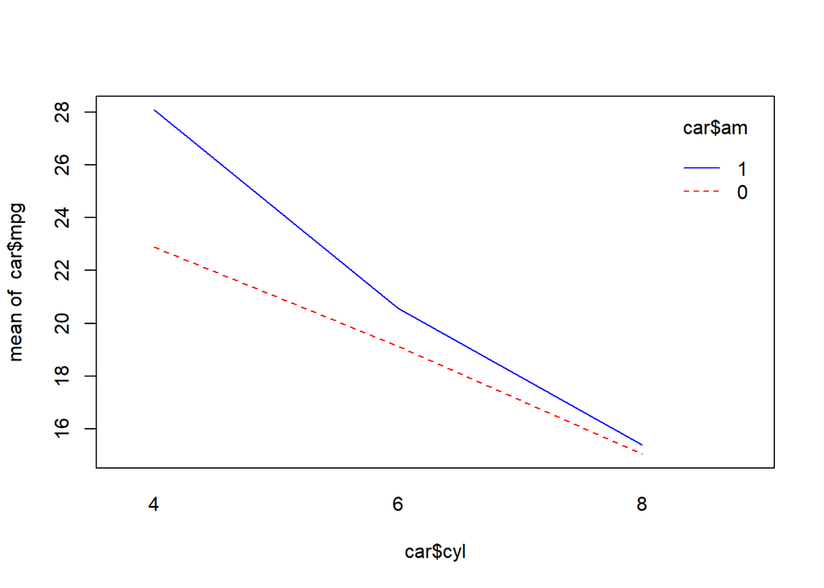

```r
interaction.plot(car$cyl, car$am, car$mpg, col = c("red", "blue"))
```

#### 상관분석 - 피어슨 상관계수 : 두 연속형 자료의 정규성 가정 - 스피어만 상관계수 : 정규성 만족X, 순위 및 순서 형태, 비모수적 방법 - 켄달의 순위상관계수 cor(x, y, method = c(“pearson”, “spearman”, “kendall”), use)

#### 상관계수 검정

- 변수 간 상관계수에 대해 추정이나 검정
- 귀무가설 : 변수1과 변수2 간에는 상관관계가 없다 cor.test(x, y, alternative = c(“two.sided”, “less”, “greater”), method = c(“pearson”, “spearman”, “kendall”))

```r
air <- airquality[, c(1:4)]

cor(air, use="pairwise.complete.obs", # use : na값 처리 방법
    # "everything" : 결측값 존재시 NA / "all.obs" : 결측값 존재시 오류 메시지
    # "complete.obs" : 변수별로 결측값 제외하고 계산
    # "pairwise.complete.obs" : 모든 변수 쌍에서 결측값이 없는 데이터들에 대해 상관계수 계산
    method="pearson") # 피어슨 상관계수 계산
cor(air, use="pairwise.complete.obs", method="kendall") # 켄달 상관계수 계산
cor(air, use="pairwise.complete.obs", method="spearman") # 스피어만 상관계수 계산
```

[output not shown]

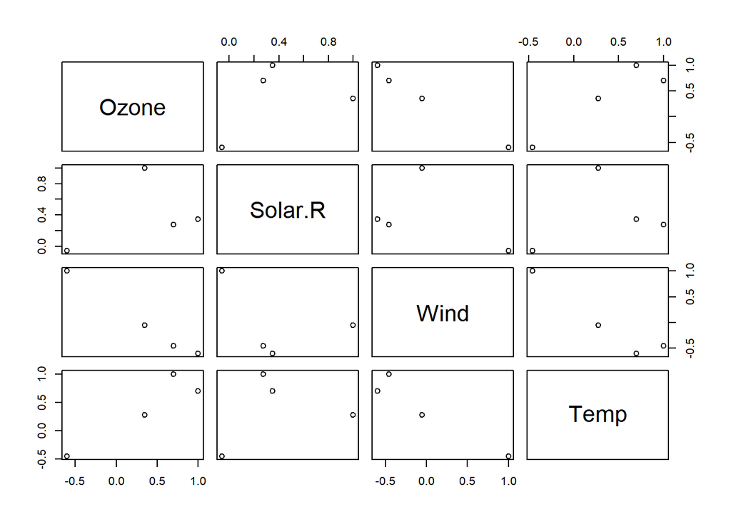

```r
air_cor<-cor(air, use="pairwise.complete.obs")
pairs(air_cor)
```

```r
library(corrplot)
```

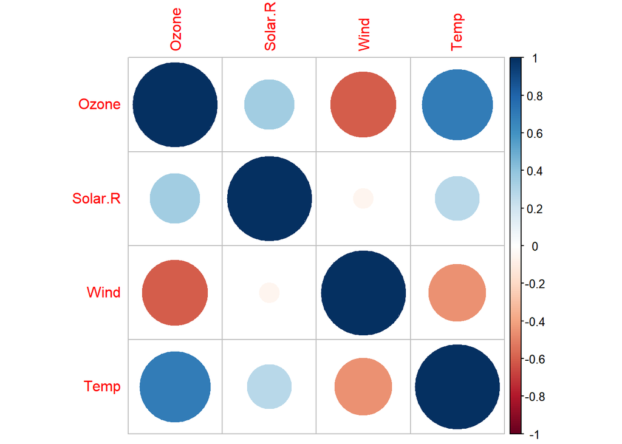

```r
corrplot(air_cor,
         "circle") # "square", "ellipse", "number", "shade", "color", "pie"
```

###### 귀무가설 : Ozone과 Wind사이에 상관관계가 없다

```r
cor.test(air$Ozone, air$Wind, method = "pearson")
```

```
##
##  Pearson's product-moment correlation
##
## data:  air$Ozone and air$Wind
## t = -8.0401, df = 114, p-value = 9.272e-13
## alternative hypothesis: true correlation is not equal to 0
## 95 percent confidence interval:
##  -0.7063918 -0.4708713
## sample estimates:
##        cor
## -0.6015465
```

#### 회귀분석

- 독립변수와 종속변수간 선형성, 오차의 독립성/등분산성/정규성

```r
Cars93_lm <- lm(Price~EngineSize, Cars93)
summary(Cars93_lm)
```

```
##
## Call:
## lm(formula = Price ~ EngineSize, data = Cars93)
##
## Residuals:
##     Min      1Q  Median      3Q     Max
## -13.684  -4.627  -1.795   2.592  39.429
##
## Coefficients:
##             Estimate Std. Error t value Pr(>|t|)
## (Intercept)   4.6692     2.2390   2.085   0.0398 *
## EngineSize    5.5629     0.7828   7.107 2.59e-10 ***
## ---
## Signif. codes:  0 '***' 0.001 '**' 0.01 '*' 0.05 '.' 0.1 ' ' 1
##
## Residual standard error: 7.789 on 91 degrees of freedom
## Multiple R-squared:  0.3569, Adjusted R-squared:  0.3499
## F-statistic: 50.51 on 1 and 91 DF,  p-value: 2.588e-10
```

- 모든 회귀계수 통계적으로 유의
- F검정 : 모형은 통계적으로 유의

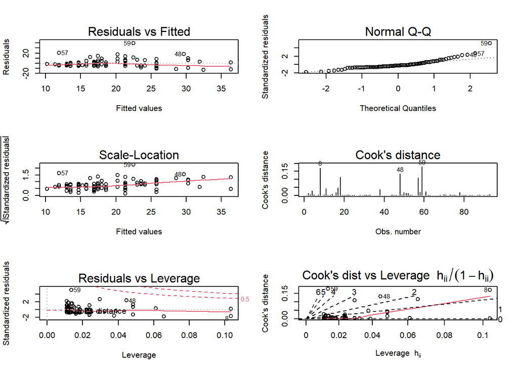

```r
par(mfrow=c(3,2))
plot(Cars93_lm, which=c(1:6))
```

- Residuals vs Fitted : 잔차 vs 적합값, 직선의 형태일수록 정규성 만족 - Normal Q-Q : 직선상에 있으면 정규성 만족 - Scale-Location : 직선의 형태일수록 이상적, 직선에서 멀리 떨어질수록 이상치 - Cook’s Distance : 한 관측치가 회귀모형에 미치는 영향을 나타내는 측도, 1이상일 경우 큰 영향을 주는 관측값 - Residuals vs Leverage : 레버리지는 관측치가 다른 관측치 집단으로부터 떨어진 정도를 나타내며, 설명변수가 극단에 치우친 정도를 표현, 쿡의 거리가 0.5이상인 빨간 점선 밖에 있는 점은 예측치를 크게 벗어난 관측치 - Cook’s Dist vs Leverage : 레버리지와 쿡의 거리는 비례관계

```r
set.seed(1234)
idx <- sample(1:nrow(Cars93), 5) ; test <- Cars93[idx,]
predict.lm(Cars93_lm, newdata = test, se = T) # 표준오차 표시
```

```
## $fit
##       28       80       22        9        5
## 21.35801 11.34472 23.02689 25.80836 24.13948
##
## $se.fit
##        28        80        22         9         5
## 0.8484817 1.4043704 0.9472153 1.1990830 1.0376351
##
## $df
## [1] 91
##
## $residual.scale
## [1] 7.788578
```

```r
predict.lm(Cars93_lm, newdata = test, interval = "confidence") # 95% 신뢰구간
```

```
##         fit       lwr      upr
## 28 21.35801 19.672604 23.04341
## 80 11.34472  8.555107 14.13433
## 22 23.02689 21.145364 24.90842
## 9  25.80836 23.426530 28.19019
## 5  24.13948 22.078345 26.20061
```

```r
predict.lm(Cars93_lm, newdata = test, interval = "prediction") # 회귀계수의 불확실성을 감안한 구간추정
```

```
##         fit       lwr      upr
## 28 21.35801  5.795423 36.92060
## 80 11.34472 -4.375825 27.06526
## 22 23.02689  7.441846 38.61194
## 9  25.80836 10.155035 41.46169
## 5  24.13948  8.531732 39.74723
```

#### 다중선형회귀분석

- 다중공선성 : 독립변수들 간 강한 상관관계 (PCA, 능형회귀)
- VIF가 10이상이면 공선성의 문제가 심각
- 더미변수 : 범주형 변수 변환

```r
iris_lm<-lm(Petal.Length~Sepal.Length+Sepal.Width+Petal.Width+Species, iris)
summary(iris_lm)
```

```
##
## Call:
## lm(formula = Petal.Length ~ Sepal.Length + Sepal.Width + Petal.Width +
##     Species, data = iris)
##
## Residuals:
##      Min       1Q   Median       3Q      Max
## -0.78396 -0.15708  0.00193  0.14730  0.65418
##
## Coefficients:
##                   Estimate Std. Error t value Pr(>|t|)
## (Intercept)       -1.11099    0.26987  -4.117 6.45e-05 ***
## Sepal.Length       0.60801    0.05024  12.101  < 2e-16 ***
## Sepal.Width       -0.18052    0.08036  -2.246   0.0262 *
## Petal.Width        0.60222    0.12144   4.959 1.97e-06 ***
## Speciesversicolor  1.46337    0.17345   8.437 3.14e-14 ***
## Speciesvirginica   1.97422    0.24480   8.065 2.60e-13 ***
## ---
## Signif. codes:  0 '***' 0.001 '**' 0.01 '*' 0.05 '.' 0.1 ' ' 1
##
## Residual standard error: 0.2627 on 144 degrees of freedom
## Multiple R-squared:  0.9786, Adjusted R-squared:  0.9778
## F-statistic:  1317 on 5 and 144 DF,  p-value: < 2.2e-16
```

```r
Price_lm<-lm(Price~EngineSize+RPM+Weight, Cars93)
summary(Price_lm)
```

```
##
## Call:
## lm(formula = Price ~ EngineSize + RPM + Weight, data = Cars93)
##
## Residuals:
##     Min      1Q  Median      3Q     Max
## -10.511  -3.806  -0.300   1.447  35.255
##
## Coefficients:
##               Estimate Std. Error t value Pr(>|t|)
## (Intercept) -51.793292   9.106309  -5.688 1.62e-07 ***
## EngineSize    4.305387   1.324961   3.249  0.00163 **
## RPM           0.007096   0.001363   5.208 1.22e-06 ***
## Weight        0.007271   0.002157   3.372  0.00111 **
## ---
## Signif. codes:  0 '***' 0.001 '**' 0.01 '*' 0.05 '.' 0.1 ' ' 1
##
## Residual standard error: 6.504 on 89 degrees of freedom
## Multiple R-squared:  0.5614, Adjusted R-squared:  0.5467
## F-statistic: 37.98 on 3 and 89 DF,  p-value: 6.746e-16
```

- 최적회귀방정식 선택 (전신선택, 후진제거, 단계적방법)

```r
lm_result<-lm(Price~EngineSize+Horsepower+RPM+Width+Length+Weight, Cars93)
step(lm_result,
      scope = list(lower = Price ~ 1, upper = Price ~ .),
     direction="backward", # forward / backward / stepwise
     k = 2) # 2 : AIC 기준 / log(n) : BIC 기준
```